# Analysing the Grocery Dataset - Aravind G

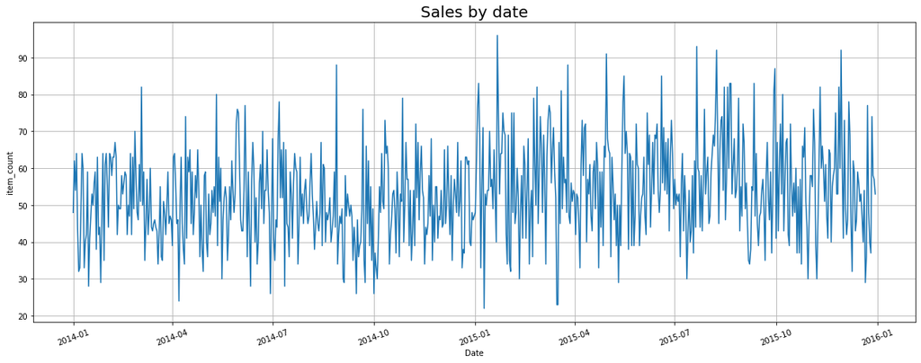

```python
%matplotlib inline
plt.figure(figsize= (20,7))
sns.lineplot(x="Date", y="item", data=sales_by_date)
plt.xticks(rotation=20)
plt.grid()
plt.xlabel("Date")
plt.ylabel("item_count")
plt.title("Sales by date",fontsize=20)
plt.show()
```

```python
sales_by_date
```

|  | Date | item |
| --- | --- | --- |
| 0 | 2014-01-01 | 48 |
| 1 | 2014-01-02 | 62 |
| 2 | 2014-01-03 | 54 |
| 3 | 2014-01-04 | 64 |
| 4 | 2014-01-05 | 44 |
| ... | ... | ... |
| 723 | 2015-12-26 | 37 |
| 724 | 2015-12-27 | 74 |
| 725 | 2015-12-28 | 58 |
| 726 | 2015-12-29 | 57 |
| 727 | 2015-12-30 | 53 |

728 rows × 2 columns

```python
sales_by_month = sales_by_date.groupby(pd.Grouper(key = 'Date',freq = 'M'))['item'].agg(['sum']).reset_index()
```

```python
sales_by_month = sales_by_month[:-1]
```

```python
sales_by_month
```

|  | Date | sum |
| --- | --- | --- |
| 0 | 2014-01-31 | 1504 |
| 1 | 2014-02-28 | 1547 |
| 2 | 2014-03-31 | 1491 |
| 3 | 2014-04-30 | 1506 |
| 4 | 2014-05-31 | 1625 |
| 5 | 2014-06-30 | 1525 |
| 6 | 2014-07-31 | 1623 |
| 7 | 2014-08-31 | 1535 |
| 8 | 2014-09-30 | 1350 |
| 9 | 2014-10-31 | 1555 |
| 10 | 2014-11-30 | 1496 |
| 11 | 2014-12-31 | 1520 |
| 12 | 2015-01-31 | 1829 |
| 13 | 2015-02-28 | 1485 |
| 14 | 2015-03-31 | 1792 |
| 15 | 2015-04-30 | 1666 |
| 16 | 2015-05-31 | 1710 |
| 17 | 2015-06-30 | 1791 |
| 18 | 2015-07-31 | 1645 |
| 19 | 2015-08-31 | 1963 |
| 20 | 2015-09-30 | 1613 |
| 21 | 2015-10-31 | 1663 |
| 22 | 2015-11-30 | 1777 |

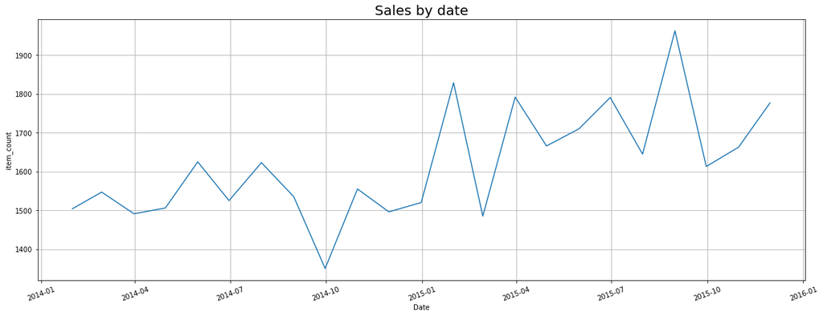

```python
#from the below graphs we can clearly see a postive trends with irregular variation
%matplotlib inline
plt.figure(figsize= (20,7))
sns.lineplot(x="Date", y="sum", data=sales_by_month)
plt.xticks(rotation=20)
plt.grid()
plt.xlabel("Date")
plt.ylabel("item_count")
plt.title("Sales by date",fontsize=20)
plt.show()
```

```python
sales_by_date = sales_by_date.sort_values(by="item",ascending=False)
sales_by_date
```

|  | Date | item |
| --- | --- | --- |
| 384 | 2015-01-21 | 96 |
| 565 | 2015-07-21 | 93 |
| 696 | 2015-11-29 | 92 |
| 583 | 2015-08-08 | 92 |
| 483 | 2015-04-30 | 91 |
| ... | ... | ... |
| 273 | 2014-10-01 | 26 |
| 96 | 2014-04-07 | 24 |
| 439 | 2015-03-17 | 23 |
| 438 | 2015-03-16 | 23 |
| 372 | 2015-01-09 | 22 |

728 rows × 2 columns

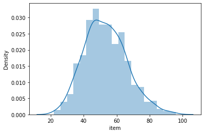

```python
sns.distplot(sales_by_date["item"]) #distribution of plot
```

```python
sales_by_date.columns
```

```
Index(['Date', 'item'], dtype='object')
```

```python
sales_by_date = remove_outlier(sales_by_date,"item")
```

```python
sales_by_date = sales_by_date.sort_values("item")
```

```python
sales_by_date
```

|  | Date | item |
| --- | --- | --- |
| 372 | 2015-01-09 | 22 |
| 438 | 2015-03-16 | 23 |
| 439 | 2015-03-17 | 23 |
| 96 | 2014-04-07 | 24 |
| 273 | 2014-10-01 | 26 |
| ... | ... | ... |
| 533 | 2015-06-19 | 85 |
| 499 | 2015-05-16 | 85 |
| 636 | 2015-09-30 | 87 |
| 448 | 2015-03-26 | 88 |
| 239 | 2014-08-28 | 88 |

723 rows × 2 columns

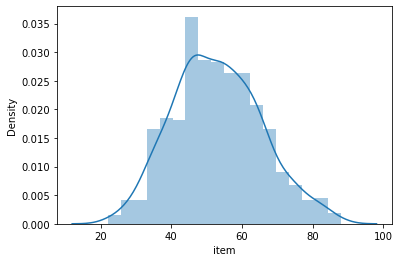

```python
sns.distplot(sales_by_date["item"])
```

```python
data["item"].value_counts()
```

```
whole milk               2502
other vegetables         1898
rolls/buns               1716
soda                     1514
yogurt                   1334
                         ...
rubbing alcohol             5
bags                        4
baby cosmetics              3
kitchen utensil             1
preservation products       1
Name: item, Length: 167, dtype: int64
```

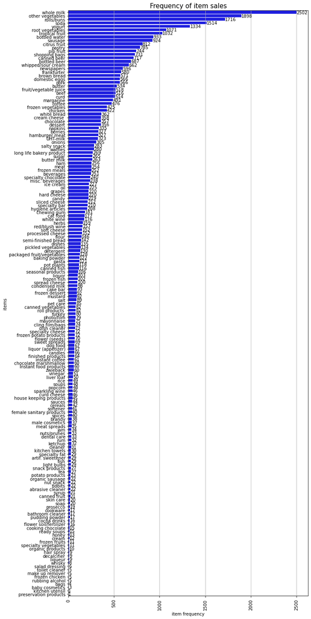

```python
plt.figure(figsize = (10,25))
plt.grid()
g = sns.barplot(x = data.item.value_counts().values,y = data.item.value_counts().keys(),color="Blue",)
plt.title("Frequency of item sales", size=15)
plt.xlabel("item frequency")
plt.ylabel("items")
plt.xticks(rotation=90)
show_values_on_bars(g,'h')
plt.show()
```

```python
sales_by_date
```

|  | Date | item |
| --- | --- | --- |
| 372 | 2015-01-09 | 22 |
| 438 | 2015-03-16 | 23 |
| 439 | 2015-03-17 | 23 |
| 96 | 2014-04-07 | 24 |
| 273 | 2014-10-01 | 26 |
| ... | ... | ... |
| 533 | 2015-06-19 | 85 |
| 499 | 2015-05-16 | 85 |
| 636 | 2015-09-30 | 87 |
| 448 | 2015-03-26 | 88 |
| 239 | 2014-08-28 | 88 |

723 rows × 2 columns

# Time Series Forcasting using Fbprophet

Prophet is a procedure for forecasting time series data based on an additive model where non-linear trends are fit with yearly, weekly, and daily seasonality, plus holiday effects. It works best with time series that have strong seasonal effects and several seasons of historical data. Prophet is robust to missing data and shifts in the trend, and typically handles outliers well.

```python
# cutoffs = pd.to_datetime(['2015-01-15', '2015-04-15', '2014-07-15'])
# param_grid = {
#     'changepoint_prior_scale': [0.001,0.05, 0.01, 0.1, 0.5],
#     'seasonality_prior_scale': [0.01, 0.1, 1.0, 10.0],
# }

# # Generate all combinations of parameters
# all_params = [dict(zip(param_grid.keys(), v)) for v in itertools.product(*param_grid.values())]
# rmses = []  # Store the RMSEs for each params here

# # Use cross validation to evaluate all parameters
# for params in all_params:
#     m = Prophet(yearly_seasonality=True,weekly_seasonality=True,**params).fit(sales_by_date)  # Fit model with given params
#     df_cv = cross_validation(m, cutoffs=cutoffs, horizon='90 days', parallel="processes")
#     df_p = performance_metrics(df_cv, rolling_window=1)
#     rmses.append(df_p['mape'].values[0])

# # Find the best parameters
# tuning_results = pd.DataFrame(all_params)
# tuning_results['mape'] = rmses
# print(tuning_results)
```

```python
model_date = Prophet()
```

```python
sales_by_date.columns = ["ds",'y']  #to use the fbprophet it is necessary to changing the coloumn name to date : ds and item_count: y
```

```python
sales_by_date
```

|  | ds | y |
| --- | --- | --- |
| 372 | 2015-01-09 | 22 |
| 438 | 2015-03-16 | 23 |
| 439 | 2015-03-17 | 23 |
| 96 | 2014-04-07 | 24 |
| 273 | 2014-10-01 | 26 |
| ... | ... | ... |
| 533 | 2015-06-19 | 85 |
| 499 | 2015-05-16 | 85 |
| 636 | 2015-09-30 | 87 |
| 448 | 2015-03-26 | 88 |
| 239 | 2014-08-28 | 88 |

723 rows × 2 columns

```python
sales_by_date.sort_index().head(5)
```

|  | ds | y |
| --- | --- | --- |
| 0 | 2014-01-01 | 48 |
| 1 | 2014-01-02 | 62 |
| 2 | 2014-01-03 | 54 |
| 3 | 2014-01-04 | 64 |
| 4 | 2014-01-05 | 44 |

```python
model_date.fit(sales_by_date) #AS default fbprophet ran with weekly seasonality
```

```
INFO:fbprophet:Disabling yearly seasonality. Run prophet with yearly_seasonality=True to override this.
INFO:fbprophet:Disabling daily seasonality. Run prophet with daily_seasonality=True to override this.
```

```
<fbprophet.forecaster.Prophet at 0x223e31ae9c8>
```

```python
model_date.component_modes
```

```
{'additive': ['weekly',
  'additive_terms',
  'extra_regressors_additive',
  'holidays'],
 'multiplicative': ['multiplicative_terms', 'extra_regressors_multiplicative']}
```

```python
future_dates = model_date.make_future_dataframe(periods=90,freq = 'D')
```

```python
future_dates.tail(5)
```

|  | ds |
| --- | --- |
| 808 | 2016-03-25 |
| 809 | 2016-03-26 |
| 810 | 2016-03-27 |
| 811 | 2016-03-28 |
| 812 | 2016-03-29 |

```python
prediction_date = model_date.predict(future_dates)
```

```python
result = prediction_date[prediction_date["ds"]>datetime.datetime(2015,12,31)]
```

```python
result.to_html("2months prediction.html")
```

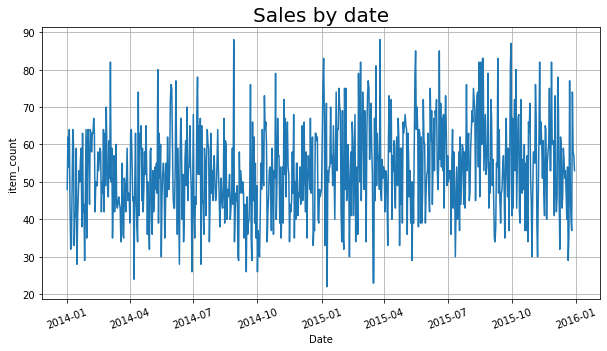

```python
plt.figure(figsize= (10,5))
sns.lineplot(x="ds", y="y", data=sales_by_date)
plt.xticks(rotation=20)
plt.grid()
plt.xlabel("Date")
plt.ylabel("item_count")
plt.title("Sales by date",fontsize=20)
plt.show()
```

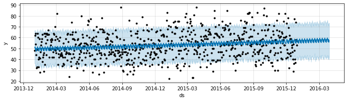

```python
model_date.plot(prediction_date,figsize=(10,3));
```

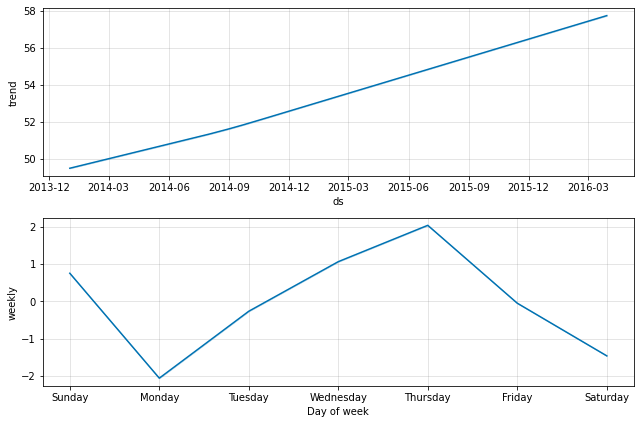

```python
model_date.plot_components(prediction_date); #plots gave me duplicate copies so used (semicolon(;))
```

```python
df_cv = cross_validation(model_date, initial='365 days', period='30 days', horizon = '60 days')
df_cv.tail(30)
```

```
INFO:fbprophet:Making 11 forecasts with cutoffs between 2015-01-04 00:00:00 and 2015-10-31 00:00:00
```

|  | ds | yhat | yhat_lower | yhat_upper | y | cutoff |
| --- | --- | --- | --- | --- | --- | --- |
| 621 | 2015-12-01 | 57.39 | 42.08 | 72.81 | 41 | 2015-10-31 |
| 622 | 2015-12-02 | 58.29 | 42.94 | 74.14 | 73 | 2015-10-31 |
| 623 | 2015-12-03 | 59.58 | 42.63 | 74.74 | 49 | 2015-10-31 |
| 624 | 2015-12-04 | 57.89 | 42.50 | 73.14 | 42 | 2015-10-31 |
| 625 | 2015-12-05 | 56.89 | 42.33 | 72.57 | 46 | 2015-10-31 |
| 626 | 2015-12-06 | 58.10 | 42.06 | 73.71 | 78 | 2015-10-31 |
| 627 | 2015-12-07 | 55.36 | 40.88 | 70.65 | 69 | 2015-10-31 |
| 628 | 2015-12-08 | 57.49 | 42.73 | 72.88 | 45 | 2015-10-31 |
| 629 | 2015-12-09 | 58.39 | 41.74 | 73.50 | 32 | 2015-10-31 |
| 630 | 2015-12-10 | 59.67 | 45.29 | 74.02 | 62 | 2015-10-31 |
| 631 | 2015-12-11 | 57.99 | 42.84 | 73.12 | 59 | 2015-10-31 |
| 632 | 2015-12-12 | 56.99 | 41.68 | 71.28 | 43 | 2015-10-31 |
| 633 | 2015-12-13 | 58.20 | 42.26 | 73.70 | 46 | 2015-10-31 |
| 634 | 2015-12-14 | 55.46 | 41.01 | 70.80 | 59 | 2015-10-31 |
| 635 | 2015-12-15 | 57.59 | 42.20 | 73.19 | 56 | 2015-10-31 |
| 636 | 2015-12-16 | 58.49 | 43.52 | 74.54 | 51 | 2015-10-31 |
| 637 | 2015-12-17 | 59.77 | 43.54 | 75.31 | 53 | 2015-10-31 |
| 638 | 2015-12-18 | 58.09 | 42.34 | 73.08 | 47 | 2015-10-31 |
| 639 | 2015-12-19 | 57.08 | 41.51 | 72.29 | 40 | 2015-10-31 |
| 640 | 2015-12-20 | 58.30 | 43.18 | 74.54 | 54 | 2015-10-31 |
| 641 | 2015-12-21 | 55.56 | 41.86 | 71.69 | 29 | 2015-10-31 |
| 642 | 2015-12-22 | 57.69 | 42.55 | 72.69 | 36 | 2015-10-31 |
| 643 | 2015-12-23 | 58.59 | 42.78 | 74.88 | 77 | 2015-10-31 |
| 644 | 2015-12-24 | 59.87 | 43.65 | 74.57 | 48 | 2015-10-31 |
| 645 | 2015-12-25 | 58.19 | 43.14 | 74.02 | 40 | 2015-10-31 |
| 646 | 2015-12-26 | 57.18 | 41.47 | 72.38 | 37 | 2015-10-31 |
| 647 | 2015-12-27 | 58.40 | 41.83 | 73.60 | 74 | 2015-10-31 |
| 648 | 2015-12-28 | 55.66 | 40.37 | 71.46 | 58 | 2015-10-31 |
| 649 | 2015-12-29 | 57.79 | 42.56 | 73.46 | 57 | 2015-10-31 |
| 650 | 2015-12-30 | 58.69 | 43.58 | 73.62 | 53 | 2015-10-31 |

```python
df_p = performance_metrics(df_cv)
df_p
```

|  | horizon | mse | rmse | mae | mape | mdape | coverage |
| --- | --- | --- | --- | --- | --- | --- | --- |
| 0 | 6 days | 182.98 | 13.53 | 11.41 | 0.23 | 0.19 | 0.63 |
| 1 | 7 days | 210.24 | 14.50 | 12.18 | 0.26 | 0.23 | 0.57 |
| 2 | 8 days | 197.69 | 14.06 | 11.67 | 0.25 | 0.19 | 0.58 |
| 3 | 9 days | 195.07 | 13.97 | 11.39 | 0.25 | 0.14 | 0.60 |
| 4 | 10 days | 202.12 | 14.22 | 11.60 | 0.25 | 0.16 | 0.62 |
| 5 | 11 days | 193.18 | 13.90 | 11.26 | 0.24 | 0.17 | 0.66 |
| 6 | 12 days | 203.38 | 14.26 | 11.52 | 0.25 | 0.16 | 0.67 |
| 7 | 13 days | 186.73 | 13.66 | 11.06 | 0.22 | 0.17 | 0.73 |
| 8 | 14 days | 189.74 | 13.77 | 11.16 | 0.23 | 0.19 | 0.73 |
| 9 | 15 days | 195.19 | 13.97 | 11.43 | 0.23 | 0.20 | 0.71 |
| 10 | 16 days | 198.55 | 14.09 | 11.47 | 0.23 | 0.20 | 0.71 |
| 11 | 17 days | 178.11 | 13.35 | 10.80 | 0.21 | 0.19 | 0.74 |
| 12 | 18 days | 156.17 | 12.50 | 10.02 | 0.18 | 0.13 | 0.78 |
| 13 | 19 days | 166.80 | 12.92 | 10.22 | 0.20 | 0.13 | 0.74 |
| 14 | 20 days | 177.44 | 13.32 | 10.48 | 0.20 | 0.12 | 0.72 |
| 15 | 21 days | 183.67 | 13.55 | 10.63 | 0.21 | 0.13 | 0.72 |
| 16 | 22 days | 160.02 | 12.65 | 9.67 | 0.18 | 0.12 | 0.76 |
| 17 | 23 days | 186.79 | 13.67 | 10.75 | 0.21 | 0.15 | 0.69 |
| 18 | 24 days | 180.78 | 13.45 | 10.57 | 0.20 | 0.15 | 0.70 |
| 19 | 25 days | 156.52 | 12.51 | 9.82 | 0.18 | 0.13 | 0.74 |
| 20 | 26 days | 165.12 | 12.85 | 10.26 | 0.19 | 0.15 | 0.71 |
| 21 | 27 days | 157.39 | 12.55 | 10.13 | 0.18 | 0.15 | 0.71 |
| 22 | 28 days | 162.10 | 12.73 | 10.47 | 0.19 | 0.15 | 0.68 |
| 23 | 29 days | 162.96 | 12.77 | 10.29 | 0.19 | 0.15 | 0.70 |
| 24 | 30 days | 173.99 | 13.19 | 10.73 | 0.21 | 0.16 | 0.67 |
| 25 | 31 days | 176.44 | 13.28 | 10.88 | 0.22 | 0.16 | 0.67 |
| 26 | 32 days | 167.20 | 12.93 | 10.58 | 0.21 | 0.17 | 0.71 |
| 27 | 33 days | 164.27 | 12.82 | 10.47 | 0.21 | 0.16 | 0.71 |
| 28 | 34 days | 172.35 | 13.13 | 10.73 | 0.21 | 0.19 | 0.69 |
| 29 | 35 days | 162.21 | 12.74 | 10.57 | 0.20 | 0.17 | 0.70 |
| 30 | 36 days | 171.34 | 13.09 | 11.03 | 0.21 | 0.20 | 0.66 |
| 31 | 37 days | 203.37 | 14.26 | 12.15 | 0.24 | 0.21 | 0.60 |
| 32 | 38 days | 193.03 | 13.89 | 11.72 | 0.24 | 0.22 | 0.62 |
| 33 | 39 days | 199.06 | 14.11 | 11.78 | 0.25 | 0.20 | 0.62 |
| 34 | 40 days | 198.68 | 14.10 | 11.72 | 0.25 | 0.20 | 0.65 |
| 35 | 41 days | 200.73 | 14.17 | 11.62 | 0.25 | 0.17 | 0.66 |
| 36 | 42 days | 207.43 | 14.40 | 11.72 | 0.26 | 0.17 | 0.69 |
| 37 | 43 days | 187.09 | 13.68 | 11.12 | 0.23 | 0.18 | 0.73 |
| 38 | 44 days | 184.21 | 13.57 | 11.07 | 0.23 | 0.18 | 0.74 |
| 39 | 45 days | 185.05 | 13.60 | 11.10 | 0.22 | 0.19 | 0.74 |
| 40 | 46 days | 191.96 | 13.85 | 11.41 | 0.23 | 0.19 | 0.71 |
| 41 | 47 days | 169.75 | 13.03 | 10.66 | 0.21 | 0.19 | 0.75 |
| 42 | 48 days | 139.50 | 11.81 | 9.57 | 0.18 | 0.15 | 0.80 |
| 43 | 49 days | 154.88 | 12.44 | 9.94 | 0.19 | 0.14 | 0.75 |
| 44 | 50 days | 167.91 | 12.96 | 10.17 | 0.20 | 0.13 | 0.72 |
| 45 | 51 days | 184.01 | 13.56 | 10.61 | 0.22 | 0.15 | 0.71 |
| 46 | 52 days | 160.06 | 12.65 | 9.67 | 0.20 | 0.11 | 0.75 |
| 47 | 53 days | 190.33 | 13.80 | 10.85 | 0.22 | 0.15 | 0.69 |
| 48 | 54 days | 184.16 | 13.57 | 10.64 | 0.22 | 0.15 | 0.70 |
| 49 | 55 days | 161.70 | 12.72 | 9.86 | 0.19 | 0.13 | 0.76 |
| 50 | 56 days | 171.17 | 13.08 | 10.40 | 0.21 | 0.15 | 0.72 |
| 51 | 57 days | 151.02 | 12.29 | 9.98 | 0.19 | 0.15 | 0.72 |
| 52 | 58 days | 158.21 | 12.58 | 10.21 | 0.19 | 0.15 | 0.69 |
| 53 | 59 days | 159.04 | 12.61 | 9.94 | 0.18 | 0.15 | 0.72 |
| 54 | 60 days | 164.45 | 12.82 | 10.20 | 0.19 | 0.15 | 0.71 |

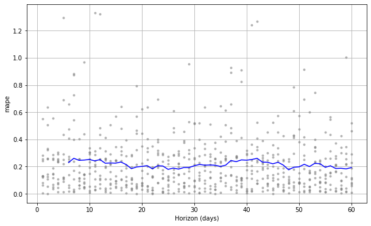

```python
fig = plot_cross_validation_metric(df_cv, metric='mape')
```

Below code is written to build a model with gropued time period - it is not necessary in fb prophet model

sales_by_week = sales_by_date.groupby(pd.Grouper(key = 'ds',freq = 'W-MON'))['y'].agg(['sum']).reset_index()

sales_by_week

model_week = Prophet(yearly_seasonality=True,seasonality_mode ='multiplicative')

sales_by_week.columns = ["ds",'y']

sales_by_week = sales_by_week[:-1] #last group dosent have 4 days

sales_by_week

sales_by_week = remove_outlier(sales_by_week , "y")

sales_by_week

model_week.fit(sales_by_week)

model_week.component_modes

future_week=model_week.make_future_dataframe(periods=52, freq = 'W-MON')

future_week

prediction_week = model_week.predict(future_week)

model_week.plot(prediction_week,figsize=(10,3))

model_week.plot_components(prediction_week)

df_cv = cross_validation(model_week, initial='365 days', period='60 days', horizon = '120 days',parallel="processes") df_cv.head

# from fbprophet.diagnostics import performance_metrics

df_p = performance_metrics(df_cv) df_p

# from fbprophet.plot import plot_cross_validation_metric

fig = plot_cross_validation_metric(df_cv, metric='mape')

type(datetime.datetime(2015,12,30))

prediction_week[prediction_week['ds']>datetime.datetime(2015,12,30)]

# Associative model

Associate model are for to do the Market Basket Analysis is a technique which identifies the strength of association between pairs of products purchased together and identify patterns of co-occurrence

Here we are using the Apriori model to do the prediction

Association rules analysis is a technique to uncover how items are associated to each other. There are three common ways to measure association.

Measure 1: Support. This says how popular an itemset is, it is number of times appear in total number of transaction. in other word we say frequency of item.

Measure 2: Confidence. This says how likely item Y is purchased when item X is purchased, expressed as {X -> Y}. This is measured by the proportion of transactions with item X, in which item Y also appears.

Measure 3: Lift. it is ratio of expected confidence to observed confidence. it is described as confidence of Y when item X was already known(x/y) to the confidence of Y when X item is unknown. in other words confidence of Y w.r.t. x and confidence of Y without X (means both are independent to each other).

support = freq of (x,y) / total no of transaction.

confidence = support ( X Union Y) / support(X).

lift = confidence/ support(Y) .

```python
#!pip install mlxtend
# from mlxtend.preprocessing import TransactionEncoder
# from mlxtend.frequent_patterns import apriori
# from mlxtend.frequent_patterns import association_rules
```

```python
data['orderID'] = data.groupby(['id','Date']).ngroup()
data = data.sort_values('orderID')
data.head(15)#there is no order id present within the data so to dermine the data has been gropued with id and date
```

|  | id | Date | item | year | month | weekday | day | day_name | weekday&weekend | orderID |
| --- | --- | --- | --- | --- | --- | --- | --- | --- | --- | --- |
| 29480 | 1000 | 2014-06-24 | pastry | 2014 | 6 | 1 | 24 | Tuesday | 0 | 0 |
| 32851 | 1000 | 2014-06-24 | salty snack | 2014 | 6 | 1 | 24 | Tuesday | 0 | 0 |
| 13331 | 1000 | 2014-06-24 | whole milk | 2014 | 6 | 1 | 24 | Tuesday | 0 | 0 |
| 8395 | 1000 | 2015-03-15 | whole milk | 2015 | 3 | 6 | 15 | Sunday | 0 | 1 |
| 20992 | 1000 | 2015-03-15 | semi-finished bread | 2015 | 3 | 6 | 15 | Sunday | 0 | 1 |
| 24544 | 1000 | 2015-03-15 | yogurt | 2015 | 3 | 6 | 15 | Sunday | 0 | 1 |
| 4843 | 1000 | 2015-03-15 | sausage | 2015 | 3 | 6 | 15 | Sunday | 0 | 1 |
| 17778 | 1000 | 2015-05-27 | pickled vegetables | 2015 | 5 | 2 | 27 | Wednesday | 0 | 2 |
| 1629 | 1000 | 2015-05-27 | soda | 2015 | 5 | 2 | 27 | Wednesday | 0 | 2 |
| 18196 | 1000 | 2015-07-24 | misc. beverages | 2015 | 7 | 4 | 24 | Friday | 0 | 3 |
| 2047 | 1000 | 2015-07-24 | canned beer | 2015 | 7 | 4 | 24 | Friday | 0 | 3 |
| 22537 | 1000 | 2015-11-25 | hygiene articles | 2015 | 11 | 2 | 25 | Wednesday | 0 | 4 |
| 6388 | 1000 | 2015-11-25 | sausage | 2015 | 11 | 2 | 25 | Wednesday | 0 | 4 |
| 32727 | 1001 | 2014-07-02 | rolls/buns | 2014 | 7 | 2 | 2 | Wednesday | 0 | 5 |
| 25540 | 1001 | 2014-07-02 | whole milk | 2014 | 7 | 2 | 2 | Wednesday | 0 | 5 |

```python
transaction = [list(data[data['orderID'] == i]['item']) for i in set(data.orderID)]
transaction[:10] #function to create a new dataset with items in same order basket
```

```
[['pastry', 'salty snack', 'whole milk'],
 ['whole milk', 'semi-finished bread', 'yogurt', 'sausage'],
 ['pickled vegetables', 'soda'],
 ['misc. beverages', 'canned beer'],
 ['hygiene articles', 'sausage'],
 ['rolls/buns', 'whole milk', 'sausage'],
 ['soda', 'whole milk'],
 ['whipped/sour cream', 'soda', 'frankfurter'],
 ['curd', 'frankfurter'],
 ['white bread', 'beef']]
```

```python
#To find the Assocition between items it is necessary to do a ecoding since it is an categorical data
transaction_encoder = TransactionEncoder()
transaction_encoder_data = transaction_encoder.fit_transform(transaction)
transactions = pd.DataFrame(transaction_encoder_data,columns=transaction_encoder.columns_)
transactions
```

|  | Instant food products | UHT-milk | abrasive cleaner | artif. sweetener | baby cosmetics | bags | baking powder | bathroom cleaner | beef | berries | ... | turkey | vinegar | waffles | whipped/sour cream | whisky | white bread | white wine | whole milk | yogurt | zwieback |
| --- | --- | --- | --- | --- | --- | --- | --- | --- | --- | --- | --- | --- | --- | --- | --- | --- | --- | --- | --- | --- | --- |
| 0 | False | False | False | False | False | False | False | False | False | False | ... | False | False | False | False | False | False | False | True | False | False |
| 1 | False | False | False | False | False | False | False | False | False | False | ... | False | False | False | False | False | False | False | True | True | False |
| 2 | False | False | False | False | False | False | False | False | False | False | ... | False | False | False | False | False | False | False | False | False | False |
| 3 | False | False | False | False | False | False | False | False | False | False | ... | False | False | False | False | False | False | False | False | False | False |
| 4 | False | False | False | False | False | False | False | False | False | False | ... | False | False | False | False | False | False | False | False | False | False |
| ... | ... | ... | ... | ... | ... | ... | ... | ... | ... | ... | ... | ... | ... | ... | ... | ... | ... | ... | ... | ... | ... |
| 14958 | False | False | False | False | False | False | False | False | False | False | ... | False | False | False | True | False | False | False | False | False | False |
| 14959 | False | False | False | False | False | False | False | False | False | False | ... | False | False | False | False | False | False | False | False | False | False |
| 14960 | False | False | False | False | False | False | False | False | False | False | ... | False | False | False | False | False | False | False | False | False | False |
| 14961 | False | False | False | False | False | False | False | False | False | False | ... | False | False | False | False | False | False | False | False | False | False |
| 14962 | False | False | False | False | False | False | False | False | False | False | ... | False | False | False | False | False | False | False | False | False | False |

14963 rows × 167 columns

```python
apriori = apriori(transactions,min_support=0.001,use_colnames=True)
```

```python
apriori.sort_values("support",ascending=False,ignore_index=True).head(10)
```

|  | support | itemsets |
| --- | --- | --- |
| 0 | 0.16 | (whole milk) |
| 1 | 0.12 | (other vegetables) |
| 2 | 0.11 | (rolls/buns) |
| 3 | 0.10 | (soda) |
| 4 | 0.09 | (yogurt) |
| 5 | 0.07 | (root vegetables) |
| 6 | 0.07 | (tropical fruit) |
| 7 | 0.06 | (bottled water) |
| 8 | 0.06 | (sausage) |
| 9 | 0.05 | (citrus fruit) |

```python
rules = association_rules(apriori, metric="confidence", min_threshold=0.01)
rules.head(15)
```

|  | antecedents | consequents | antecedent support | consequent support | support | confidence | lift | leverage | conviction |
| --- | --- | --- | --- | --- | --- | --- | --- | --- | --- |
| 0 | (bottled water) | (UHT-milk) | 0.06 | 0.02 | 0.00 | 0.02 | 0.82 | -0.00 | 1.00 |
| 1 | (UHT-milk) | (bottled water) | 0.02 | 0.06 | 0.00 | 0.05 | 0.82 | -0.00 | 0.99 |
| 2 | (other vegetables) | (UHT-milk) | 0.12 | 0.02 | 0.00 | 0.02 | 0.82 | -0.00 | 1.00 |
| 3 | (UHT-milk) | (other vegetables) | 0.02 | 0.12 | 0.00 | 0.10 | 0.82 | -0.00 | 0.98 |
| 4 | (rolls/buns) | (UHT-milk) | 0.11 | 0.02 | 0.00 | 0.02 | 0.77 | -0.00 | 0.99 |
| 5 | (UHT-milk) | (rolls/buns) | 0.02 | 0.11 | 0.00 | 0.08 | 0.77 | -0.00 | 0.97 |
| 6 | (root vegetables) | (UHT-milk) | 0.07 | 0.02 | 0.00 | 0.01 | 0.67 | -0.00 | 0.99 |
| 7 | (UHT-milk) | (root vegetables) | 0.02 | 0.07 | 0.00 | 0.05 | 0.67 | -0.00 | 0.98 |
| 8 | (sausage) | (UHT-milk) | 0.06 | 0.02 | 0.00 | 0.02 | 0.88 | -0.00 | 1.00 |
| 9 | (UHT-milk) | (sausage) | 0.02 | 0.06 | 0.00 | 0.05 | 0.88 | -0.00 | 0.99 |
| 10 | (soda) | (UHT-milk) | 0.10 | 0.02 | 0.00 | 0.01 | 0.61 | -0.00 | 0.99 |
| 11 | (UHT-milk) | (soda) | 0.02 | 0.10 | 0.00 | 0.06 | 0.61 | -0.00 | 0.96 |
| 12 | (tropical fruit) | (UHT-milk) | 0.07 | 0.02 | 0.00 | 0.02 | 1.06 | 0.00 | 1.00 |
| 13 | (UHT-milk) | (tropical fruit) | 0.02 | 0.07 | 0.00 | 0.07 | 1.06 | 0.00 | 1.00 |
| 14 | (UHT-milk) | (whole milk) | 0.02 | 0.16 | 0.00 | 0.12 | 0.75 | -0.00 | 0.96 |

```python
basket = rules[ (rules['lift'] >= 1) & (rules['confidence'] >= 0.10) ].sort_values(["confidence","lift"],ascending=False)
```

```python
basket = basket.reset_index(drop=True)
```

```python
basket
```

|  | antecedents | consequents | antecedent support | consequent support | support | confidence | lift | leverage | conviction |
| --- | --- | --- | --- | --- | --- | --- | --- | --- | --- |
| 0 | (sausage, yogurt) | (whole milk) | 0.01 | 0.16 | 0.00 | 0.26 | 1.62 | 0.00 | 1.13 |
| 1 | (rolls/buns, sausage) | (whole milk) | 0.01 | 0.16 | 0.00 | 0.21 | 1.35 | 0.00 | 1.07 |
| 2 | (soda, sausage) | (whole milk) | 0.01 | 0.16 | 0.00 | 0.18 | 1.14 | 0.00 | 1.03 |
| 3 | (semi-finished bread) | (whole milk) | 0.01 | 0.16 | 0.00 | 0.18 | 1.11 | 0.00 | 1.02 |
| 4 | (rolls/buns, yogurt) | (whole milk) | 0.01 | 0.16 | 0.00 | 0.17 | 1.08 | 0.00 | 1.02 |
| 5 | (sausage, whole milk) | (yogurt) | 0.01 | 0.09 | 0.00 | 0.16 | 1.91 | 0.00 | 1.09 |
| 6 | (detergent) | (whole milk) | 0.01 | 0.16 | 0.00 | 0.16 | 1.03 | 0.00 | 1.01 |
| 7 | (ham) | (whole milk) | 0.02 | 0.16 | 0.00 | 0.16 | 1.01 | 0.00 | 1.00 |
| 8 | (processed cheese) | (rolls/buns) | 0.01 | 0.11 | 0.00 | 0.14 | 1.32 | 0.00 | 1.04 |
| 9 | (packaged fruit/vegetables) | (rolls/buns) | 0.01 | 0.11 | 0.00 | 0.14 | 1.29 | 0.00 | 1.04 |
| 10 | (seasonal products) | (rolls/buns) | 0.01 | 0.11 | 0.00 | 0.14 | 1.29 | 0.00 | 1.04 |
| 11 | (rolls/buns, soda) | (other vegetables) | 0.01 | 0.12 | 0.00 | 0.14 | 1.15 | 0.00 | 1.02 |
| 12 | (frankfurter) | (other vegetables) | 0.04 | 0.12 | 0.01 | 0.14 | 1.12 | 0.00 | 1.02 |
| 13 | (whole milk, yogurt) | (sausage) | 0.01 | 0.06 | 0.00 | 0.13 | 2.18 | 0.00 | 1.08 |
| 14 | (pot plants) | (other vegetables) | 0.01 | 0.12 | 0.00 | 0.13 | 1.05 | 0.00 | 1.01 |
| 15 | (frozen meals) | (other vegetables) | 0.02 | 0.12 | 0.00 | 0.13 | 1.04 | 0.00 | 1.01 |
| 16 | (red/blush wine) | (rolls/buns) | 0.01 | 0.11 | 0.00 | 0.13 | 1.16 | 0.00 | 1.02 |
| 17 | (meat) | (other vegetables) | 0.02 | 0.12 | 0.00 | 0.13 | 1.04 | 0.00 | 1.01 |
| 18 | (sausage, whole milk) | (rolls/buns) | 0.01 | 0.11 | 0.00 | 0.13 | 1.15 | 0.00 | 1.02 |
| 19 | (soft cheese) | (yogurt) | 0.01 | 0.09 | 0.00 | 0.13 | 1.47 | 0.00 | 1.05 |
| 20 | (detergent) | (yogurt) | 0.01 | 0.09 | 0.00 | 0.12 | 1.44 | 0.00 | 1.04 |
| 21 | (berries) | (other vegetables) | 0.02 | 0.12 | 0.00 | 0.12 | 1.00 | 0.00 | 1.00 |
| 22 | (oil) | (soda) | 0.01 | 0.10 | 0.00 | 0.12 | 1.25 | 0.00 | 1.03 |
| 23 | (whole milk, yogurt) | (rolls/buns) | 0.01 | 0.11 | 0.00 | 0.12 | 1.09 | 0.00 | 1.01 |
| 24 | (sausage, whole milk) | (soda) | 0.01 | 0.10 | 0.00 | 0.12 | 1.23 | 0.00 | 1.03 |
| 25 | (chocolate) | (rolls/buns) | 0.02 | 0.11 | 0.00 | 0.12 | 1.08 | 0.00 | 1.01 |
| 26 | (soda, other vegetables) | (rolls/buns) | 0.01 | 0.11 | 0.00 | 0.12 | 1.07 | 0.00 | 1.01 |
| 27 | (chewing gum) | (yogurt) | 0.01 | 0.09 | 0.00 | 0.12 | 1.36 | 0.00 | 1.03 |
| 28 | (detergent) | (rolls/buns) | 0.01 | 0.11 | 0.00 | 0.12 | 1.06 | 0.00 | 1.01 |
| 29 | (ice cream) | (rolls/buns) | 0.02 | 0.11 | 0.00 | 0.11 | 1.04 | 0.00 | 1.01 |
| 30 | (hard cheese) | (rolls/buns) | 0.01 | 0.11 | 0.00 | 0.11 | 1.03 | 0.00 | 1.00 |
| 31 | (beverages) | (soda) | 0.02 | 0.10 | 0.00 | 0.11 | 1.16 | 0.00 | 1.02 |
| 32 | (fruit/vegetable juice) | (rolls/buns) | 0.03 | 0.11 | 0.00 | 0.11 | 1.00 | 0.00 | 1.00 |
| 33 | (flour) | (tropical fruit) | 0.01 | 0.07 | 0.00 | 0.11 | 1.62 | 0.00 | 1.05 |
| 34 | (herbs) | (yogurt) | 0.01 | 0.09 | 0.00 | 0.11 | 1.25 | 0.00 | 1.02 |
| 35 | (rolls/buns, other vegetables) | (soda) | 0.01 | 0.10 | 0.00 | 0.11 | 1.11 | 0.00 | 1.01 |
| 36 | (processed cheese) | (root vegetables) | 0.01 | 0.07 | 0.00 | 0.11 | 1.51 | 0.00 | 1.04 |

```python
basket.to_csv("basket_association.csv")
```

```python
rules.sort_values('confidence', ascending = False, inplace=True)
rules.head(15)
```

|  | antecedents | consequents | antecedent support | consequent support | support | confidence | lift | leverage | conviction |
| --- | --- | --- | --- | --- | --- | --- | --- | --- | --- |
| 1195 | (sausage, yogurt) | (whole milk) | 0.01 | 0.16 | 0.00 | 0.26 | 1.62 | 0.00 | 1.13 |
| 1176 | (rolls/buns, sausage) | (whole milk) | 0.01 | 0.16 | 0.00 | 0.21 | 1.35 | 0.00 | 1.07 |
| 1190 | (soda, sausage) | (whole milk) | 0.01 | 0.16 | 0.00 | 0.18 | 1.14 | 0.00 | 1.03 |
| 1087 | (semi-finished bread) | (whole milk) | 0.01 | 0.16 | 0.00 | 0.18 | 1.11 | 0.00 | 1.02 |
| 1185 | (rolls/buns, yogurt) | (whole milk) | 0.01 | 0.16 | 0.00 | 0.17 | 1.08 | 0.00 | 1.02 |
| 1197 | (sausage, whole milk) | (yogurt) | 0.01 | 0.09 | 0.00 | 0.16 | 1.91 | 0.00 | 1.09 |
| 580 | (detergent) | (whole milk) | 0.01 | 0.16 | 0.00 | 0.16 | 1.03 | 0.00 | 1.01 |
| 721 | (ham) | (whole milk) | 0.02 | 0.16 | 0.00 | 0.16 | 1.01 | 0.00 | 1.00 |
| 148 | (bottled beer) | (whole milk) | 0.05 | 0.16 | 0.01 | 0.16 | 1.00 | -0.00 | 1.00 |
| 648 | (frozen fish) | (whole milk) | 0.01 | 0.16 | 0.00 | 0.16 | 0.99 | -0.00 | 1.00 |
| 313 | (candy) | (whole milk) | 0.01 | 0.16 | 0.00 | 0.15 | 0.94 | -0.00 | 0.99 |
| 1083 | (sausage) | (whole milk) | 0.06 | 0.16 | 0.01 | 0.15 | 0.94 | -0.00 | 0.99 |
| 895 | (onions) | (whole milk) | 0.02 | 0.16 | 0.00 | 0.15 | 0.92 | -0.00 | 0.99 |
| 1004 | (processed cheese) | (rolls/buns) | 0.01 | 0.11 | 0.00 | 0.14 | 1.32 | 0.00 | 1.04 |
| 1008 | (processed cheese) | (whole milk) | 0.01 | 0.16 | 0.00 | 0.14 | 0.92 | -0.00 | 0.98 |

```python
rules.sort_values('lift', ascending = False, inplace=True)
rules.head(15)
```

|  | antecedents | consequents | antecedent support | consequent support | support | confidence | lift | leverage | conviction |
| --- | --- | --- | --- | --- | --- | --- | --- | --- | --- |
| 1196 | (whole milk, yogurt) | (sausage) | 0.01 | 0.06 | 0.00 | 0.13 | 2.18 | 0.00 | 1.08 |
| 1199 | (sausage) | (whole milk, yogurt) | 0.06 | 0.01 | 0.00 | 0.02 | 2.18 | 0.00 | 1.01 |
| 1197 | (sausage, whole milk) | (yogurt) | 0.01 | 0.09 | 0.00 | 0.16 | 1.91 | 0.00 | 1.09 |
| 1198 | (yogurt) | (sausage, whole milk) | 0.09 | 0.01 | 0.00 | 0.02 | 1.91 | 0.00 | 1.01 |
| 472 | (specialty chocolate) | (citrus fruit) | 0.02 | 0.05 | 0.00 | 0.09 | 1.65 | 0.00 | 1.04 |
| 471 | (citrus fruit) | (specialty chocolate) | 0.05 | 0.02 | 0.00 | 0.03 | 1.65 | 0.00 | 1.01 |
| 1195 | (sausage, yogurt) | (whole milk) | 0.01 | 0.16 | 0.00 | 0.26 | 1.62 | 0.00 | 1.13 |
| 614 | (tropical fruit) | (flour) | 0.07 | 0.01 | 0.00 | 0.02 | 1.62 | 0.00 | 1.01 |
| 613 | (flour) | (tropical fruit) | 0.01 | 0.07 | 0.00 | 0.11 | 1.62 | 0.00 | 1.05 |
| 91 | (beverages) | (sausage) | 0.02 | 0.06 | 0.00 | 0.09 | 1.54 | 0.00 | 1.04 |
| 90 | (sausage) | (beverages) | 0.06 | 0.02 | 0.00 | 0.03 | 1.54 | 0.00 | 1.01 |
| 1194 | (sausage) | (soda, whole milk) | 0.06 | 0.01 | 0.00 | 0.02 | 1.52 | 0.00 | 1.01 |
| 1191 | (soda, whole milk) | (sausage) | 0.01 | 0.06 | 0.00 | 0.09 | 1.52 | 0.00 | 1.03 |
| 836 | (napkins) | (pastry) | 0.02 | 0.05 | 0.00 | 0.08 | 1.52 | 0.00 | 1.03 |
| 835 | (pastry) | (napkins) | 0.05 | 0.02 | 0.00 | 0.03 | 1.52 | 0.00 | 1.01 |

```python
rules.sort_values('lift', ascending = True, inplace=True)
rules.head(15)
```

|  | antecedents | consequents | antecedent support | consequent support | support | confidence | lift | leverage | conviction |
| --- | --- | --- | --- | --- | --- | --- | --- | --- | --- |
| 465 | (citrus fruit) | (sausage) | 0.05 | 0.06 | 0.00 | 0.02 | 0.38 | -0.00 | 0.96 |
| 466 | (sausage) | (citrus fruit) | 0.06 | 0.05 | 0.00 | 0.02 | 0.38 | -0.00 | 0.97 |
| 48 | (rolls/buns) | (beef) | 0.11 | 0.03 | 0.00 | 0.01 | 0.43 | -0.00 | 0.98 |
| 49 | (beef) | (rolls/buns) | 0.03 | 0.11 | 0.00 | 0.05 | 0.43 | -0.00 | 0.93 |
| 56 | (tropical fruit) | (beef) | 0.07 | 0.03 | 0.00 | 0.02 | 0.49 | -0.00 | 0.98 |
| 57 | (beef) | (tropical fruit) | 0.03 | 0.07 | 0.00 | 0.03 | 0.49 | -0.00 | 0.96 |
| 237 | (root vegetables) | (brown bread) | 0.07 | 0.04 | 0.00 | 0.02 | 0.51 | -0.00 | 0.98 |
| 236 | (brown bread) | (root vegetables) | 0.04 | 0.07 | 0.00 | 0.04 | 0.51 | -0.00 | 0.96 |
| 157 | (canned beer) | (bottled water) | 0.05 | 0.06 | 0.00 | 0.03 | 0.52 | -0.00 | 0.97 |
| 156 | (bottled water) | (canned beer) | 0.06 | 0.05 | 0.00 | 0.02 | 0.52 | -0.00 | 0.98 |
| 397 | (root vegetables) | (chicken) | 0.07 | 0.03 | 0.00 | 0.01 | 0.52 | -0.00 | 0.99 |
| 398 | (chicken) | (root vegetables) | 0.03 | 0.07 | 0.00 | 0.04 | 0.52 | -0.00 | 0.97 |
| 1155 | (yogurt) | (white bread) | 0.09 | 0.02 | 0.00 | 0.01 | 0.52 | -0.00 | 0.99 |
| 1154 | (white bread) | (yogurt) | 0.02 | 0.09 | 0.00 | 0.04 | 0.52 | -0.00 | 0.96 |
| 774 | (long life bakery product) | (other vegetables) | 0.02 | 0.12 | 0.00 | 0.06 | 0.52 | -0.00 | 0.94 |

```python
rules.sort_values('support', ascending = False, inplace=True)
rules.head(15)
```

|  | antecedents | consequents | antecedent support | consequent support | support | confidence | lift | leverage | conviction |
| --- | --- | --- | --- | --- | --- | --- | --- | --- | --- |
| 937 | (other vegetables) | (whole milk) | 0.12 | 0.16 | 0.01 | 0.12 | 0.77 | -0.00 | 0.96 |
| 938 | (whole milk) | (other vegetables) | 0.16 | 0.12 | 0.01 | 0.09 | 0.77 | -0.00 | 0.97 |
| 1036 | (whole milk) | (rolls/buns) | 0.16 | 0.11 | 0.01 | 0.09 | 0.80 | -0.00 | 0.98 |
| 1035 | (rolls/buns) | (whole milk) | 0.11 | 0.16 | 0.01 | 0.13 | 0.80 | -0.00 | 0.96 |
| 1115 | (whole milk) | (soda) | 0.16 | 0.10 | 0.01 | 0.07 | 0.76 | -0.00 | 0.97 |
| 1114 | (soda) | (whole milk) | 0.10 | 0.16 | 0.01 | 0.12 | 0.76 | -0.00 | 0.96 |
| 1157 | (yogurt) | (whole milk) | 0.09 | 0.16 | 0.01 | 0.13 | 0.82 | -0.00 | 0.97 |
| 1158 | (whole milk) | (yogurt) | 0.16 | 0.09 | 0.01 | 0.07 | 0.82 | -0.00 | 0.98 |
| 907 | (rolls/buns) | (other vegetables) | 0.11 | 0.12 | 0.01 | 0.10 | 0.79 | -0.00 | 0.97 |
| 908 | (other vegetables) | (rolls/buns) | 0.12 | 0.11 | 0.01 | 0.09 | 0.79 | -0.00 | 0.97 |
| 920 | (soda) | (other vegetables) | 0.10 | 0.12 | 0.01 | 0.10 | 0.82 | -0.00 | 0.98 |
| 921 | (other vegetables) | (soda) | 0.12 | 0.10 | 0.01 | 0.08 | 0.82 | -0.00 | 0.98 |
| 1083 | (sausage) | (whole milk) | 0.06 | 0.16 | 0.01 | 0.15 | 0.94 | -0.00 | 0.99 |
| 1084 | (whole milk) | (sausage) | 0.16 | 0.06 | 0.01 | 0.06 | 0.94 | -0.00 | 1.00 |
| 1139 | (whole milk) | (tropical fruit) | 0.16 | 0.07 | 0.01 | 0.05 | 0.77 | -0.00 | 0.98 |

# Machine Learning model

```python
data
```

|  | id | Date | item | year | month | weekday | day | day_name | weekday&weekend | orderID |
| --- | --- | --- | --- | --- | --- | --- | --- | --- | --- | --- |
| 29480 | 1000 | 2014-06-24 | pastry | 2014 | 6 | 1 | 24 | Tuesday | 0 | 0 |
| 32851 | 1000 | 2014-06-24 | salty snack | 2014 | 6 | 1 | 24 | Tuesday | 0 | 0 |
| 13331 | 1000 | 2014-06-24 | whole milk | 2014 | 6 | 1 | 24 | Tuesday | 0 | 0 |
| 8395 | 1000 | 2015-03-15 | whole milk | 2015 | 3 | 6 | 15 | Sunday | 0 | 1 |
| 20992 | 1000 | 2015-03-15 | semi-finished bread | 2015 | 3 | 6 | 15 | Sunday | 0 | 1 |
| ... | ... | ... | ... | ... | ... | ... | ... | ... | ... | ... |
| 9340 | 5000 | 2014-11-16 | bottled beer | 2014 | 11 | 6 | 16 | Sunday | 0 | 14961 |
| 25489 | 5000 | 2014-11-16 | other vegetables | 2014 | 11 | 6 | 16 | Sunday | 0 | 14961 |
| 3578 | 5000 | 2015-10-02 | soda | 2015 | 10 | 4 | 2 | Friday | 0 | 14962 |
| 34885 | 5000 | 2015-10-02 | semi-finished bread | 2015 | 10 | 4 | 2 | Friday | 0 | 14962 |
| 19727 | 5000 | 2015-10-02 | root vegetables | 2015 | 10 | 4 | 2 | Friday | 0 | 14962 |

38765 rows × 10 columns

```python
data_class = data[["month","weekday","day","item"]]
```

```python
data_class["sales"] = data_class.groupby(["item","month"]).ngroup()
```

```python
groupeddata = data_class.groupby(["item","month"])["sales"].count().reset_index()
```

```python
groupeddata.sort_values("sales")
```

|  | item | month | sales |
| --- | --- | --- | --- |
| 636 | frozen chicken | 11 | 1 |
| 1352 | rubbing alcohol | 4 | 1 |
| 562 | female sanitary products | 9 | 1 |
| 1289 | ready soups | 10 | 1 |
| 1288 | ready soups | 8 | 1 |
| ... | ... | ... | ... |
| 1786 | whole milk | 5 | 218 |
| 1782 | whole milk | 1 | 219 |
| 1788 | whole milk | 7 | 222 |
| 1792 | whole milk | 11 | 230 |
| 1789 | whole milk | 8 | 235 |

1818 rows × 3 columns

```python
from sklearn.preprocessing import LabelEncoder
```

```python
le = LabelEncoder()
```

```python
le.fit(groupeddata["item"])
```

```
LabelEncoder()
```

```python
groupeddata["item_code"] = le.transform(groupeddata["item"])
```

```python
finilized_data = groupeddata[["month","item_code","sales"]]
```

```python
x = finilized_data[["month","item_code"]]
y = finilized_data["sales"]
```

```python
# from lazypredict.Supervised import LazyRegressor
# from sklearn.model_selection import train_test_split
```

```python
x_train, x_test, y_train, y_test = train_test_split(x, y,test_size=0.70,random_state =123)
```

```python
#Lazy predict to compare multiple regression models
clf = LazyRegressor(verbose=0,ignore_warnings=True, custom_metric=None)
models,predictions = clf.fit(x_train, x_test, y_train, y_test)

print(models)
```

```
                               R-Squared  RMSE  Time Taken
Model
XGBRegressor                        0.90 10.05        0.94
DecisionTreeRegressor               0.88 11.22        0.01
RandomForestRegressor               0.79 14.70        0.21
GradientBoostingRegressor           0.78 15.20        0.06
BaggingRegressor                    0.70 17.57        0.03
ExtraTreesRegressor                 0.41 24.59        0.14
HistGradientBoostingRegressor       0.41 24.71        0.44
LGBMRegressor                       0.33 26.31        0.14
AdaBoostRegressor                   0.31 26.60        0.03
MLPRegressor                        0.02 31.75        0.54
OrthogonalMatchingPursuit           0.02 31.83        0.01
PoissonRegressor                    0.01 31.87        0.01
Lasso                               0.01 31.88        0.01
ElasticNetCV                        0.01 31.90        0.06
BayesianRidge                       0.01 31.90        0.01
ElasticNet                          0.01 31.91        0.01
RidgeCV                             0.01 31.91        0.01
LassoCV                             0.01 31.92        0.05
Ridge                               0.01 31.92        0.01
TransformedTargetRegressor          0.01 31.92        0.01
LinearRegression                    0.01 31.92        0.01
Lars                                0.01 31.92        0.01
LassoLarsCV                         0.01 31.92        0.01
LassoLarsIC                         0.01 31.92        0.01
OrthogonalMatchingPursuitCV         0.01 31.92        0.01
LarsCV                              0.01 31.92        0.02
SGDRegressor                        0.01 31.92        0.01
GammaRegressor                      0.01 31.92        0.01
TweedieRegressor                    0.01 31.92        0.01
GeneralizedLinearRegressor          0.01 31.92        0.01
DummyRegressor                     -0.00 32.08        0.01
LassoLars                          -0.00 32.08        0.01
ExtraTreeRegressor                 -0.04 32.70        0.01
NuSVR                              -0.05 32.86        0.02
PassiveAggressiveRegressor         -0.05 32.87        0.01
HuberRegressor                     -0.09 33.51        0.02
KNeighborsRegressor                -0.13 34.12        0.02
SVR                                -0.15 34.36        0.04
LinearSVR                          -0.16 34.51        0.01
RANSACRegressor                    -0.28 36.30        0.03
GaussianProcessRegressor           -0.32 36.87        0.06
KernelRidge                        -0.44 38.52        0.03
```

```python
# from xgboost import XGBRegressor
# from sklearn.metrics import r2_score
```

```python
final_model = XGBRegressor()
```

```python
final_model.fit(x_train,y_train)
```

```
XGBRegressor(base_score=0.5, booster='gbtree', colsample_bylevel=1,
             colsample_bynode=1, colsample_bytree=1, gamma=0, gpu_id=-1,
             importance_type='gain', interaction_constraints='',
             learning_rate=0.300000012, max_delta_step=0, max_depth=6,
             min_child_weight=1, missing=nan, monotone_constraints='()',
             n_estimators=100, n_jobs=8, num_parallel_tree=1, random_state=0,
             reg_alpha=0, reg_lambda=1, scale_pos_weight=1, subsample=1,
             tree_method='exact', validate_parameters=1, verbosity=None)
```

```python
y_pred = final_model.predict(x_test)
```

```python
r2_score(y_test,y_pred)
```

```
0.9026743236373518
```

```python
x_test = x_test.reset_index()
```

```python
x_test.drop('index',axis = 1)
```

|  | month | item_code |
| --- | --- | --- |
| 0 | 2 | 65 |
| 1 | 9 | 165 |
| 2 | 11 | 118 |
| 3 | 2 | 21 |
| 4 | 10 | 128 |
| ... | ... | ... |
| 1268 | 3 | 23 |
| 1269 | 8 | 150 |
| 1270 | 11 | 85 |
| 1271 | 4 | 41 |
| 1272 | 9 | 48 |

1273 rows × 2 columns

```python
pd.Series(y_pred)
```

```
0       15.36
1      109.32
2       10.52
3        3.55
4       16.71
        ...
1268     8.12
1269    16.86
1270    12.90
1271     3.90
1272     5.23
Length: 1273, dtype: float32
```

```python
results = pd.concat([x_test,pd.Series(y_pred)],axis=1)
```

```python
results.drop('index',axis = 1)
```

|  | month | item_code | 0 |
| --- | --- | --- | --- |
| 0 | 2 | 65 | 15.36 |
| 1 | 9 | 165 | 109.32 |
| 2 | 11 | 118 | 10.52 |
| 3 | 2 | 21 | 3.55 |
| 4 | 10 | 128 | 16.71 |
| ... | ... | ... | ... |
| 1268 | 3 | 23 | 8.12 |
| 1269 | 8 | 150 | 16.86 |
| 1270 | 11 | 85 | 12.90 |
| 1271 | 4 | 41 | 3.90 |
| 1272 | 9 | 48 | 5.23 |

1273 rows × 3 columns